# Estimating temporary populations: a systematic review of the empirical literature

Radoslaw Panczak, Elin Charles-Edwards, Jonathan Corcoran

# Background

Conventional population estimates capture a population at a single point in time. Such estimates ignore the short-term dynamism of many populations caused by temporary population mobility, territorial movement which does not result in a permanent change of usual residence (Bell and Ward 2000). Temporary population movements are defined as moves of one or more night’s duration, but can be broadened to include diurnal movements such as daily commuting (Smith 1989). Temporary mobility can have a large impact on the size and composition of small area populations (Charles-Edwards and Panczak 2018) impacting traffic, housing, retail sales, medical services and emergency preparedness to name a select few (Smith 1989; Smith and House 2007). As a consequence, there is growing interest and need for temporary population estimates across a broad range of purposes including the planning and delivery of goods and services, fiscal equalisation (Graebert, Wyckoff, and Bretz 2014), retail analysis, transport demand, emergency preparedness, and as better denominators for crime and epidemiological models (Charles-Edwards et al. n.d.).

Scholarship concerned with developing the conceptual aspects of temporary populations has seen a longstanding interest with early work appearing in the Unites States in the 1950s (Foley 1954; Schmitt 1956). This early work proposed building on traditional demographic approaches to generate temporary population estimates and was first to recognise the potential value of symptomatic data as a source for such statistics. Several decades later it was Smith (1987, 1989) that proposed set of metrics (visitor-days and visitor-years) to capture measures of population present as well as highlighting the difficulty of validating estimates of temporary populations. More recently, Bell (2000, 2004) argued that estimates of temporary populations are contingent on developing a rigorous understanding of temporary population mobility. Here he drew attention to four dimensions (movement intensity, duration, seasonality and spatial impact) which he argued are associated with temporary mobility and that drive the change in stock of temporary visitors at both the origin and at the destination.

Despite growing interest in temporary population statistics, they still do not form part of the standard suite of any official population statistics. Historically, this been due to a lack of data capturing temporary populations, but also nascent conceptualisation of temporary populations and lack of standard methodologies for their production. Indeed, Smith (1989), in his seminal paper on the estimation of temporary populations, noted that the development of a methodology applicable across a wide range of population and scenarios was ‘most likely impossible’. He could not have predicted the proliferation of geo-located data from mobile phones and other technologies in the 21st Century with potential for the sensing of temporary populations across large geographic areas and in widely differing contexts. The current study assesses progress in the field of temporary population statistics. To this end, we conduct a mixed method review of the international literature on the estimation of temporary populations to identify the contemporary state of the art. To this end the study seeks to understand the volume, geography, population coverage along with the data and methods used to generate temporary population estimates, and investigate how such estimates might be reconciled alongside traditional population statistics.

The remainder of the paper is structured as follows: In Section 2 we detail the adopted methods including information sources and search terms, eligibility criteria and data extraction. In Section 3, we report results of the review examining both theoretical and applied work. In the final sections of the paper we summarise the current start of the art and make a series of recommendations for the production of temporary population statistics.

# Methods: Protocol and capture

The review was conducted using the principles of the PRISMA Statement for Reporting Systematic Reviews (Moher et al. 2009). In order to deal with complexity and lack of standarization in the field and to account for theory-building character of this work we additionally adopted “mixed-method review” methodology (Gough 2015). That allowed us to combine methods of a systematic review (selection of keywords and sources, eligibility criteria, etc.) with the openness and flexibility of traditional reviews.

Articles that form the basis of the review were captured via search of four databases; (1) Web of Science; (2) Scopus; (3) Google Scholar; and, (4) arXiv. All databases were searched using a set of keywords that collectively encompass the breadth of synonyms for temporary populations. More specifically we employed a suite of terms that were derived from the authors existing knowledge of the field, as well as key terms that emerged during early stages of the review process. Terms included: “temporary population”, “working population”, “daytime population”, “mobile population”, “service population”, “floating population”, “elusive population”, “ambient population”, “seasonal population”, “non-resident population”, “real-time census”, “social sensing” and “spatiotemporal population”. We additionally scrutinised the reference lists of included studies to ensure full coverage of articles. Last searches were conducted on the 24 November 2017. In order to to enhance the currency and coverage of the articles captured we adopted some of the principles of living systematic review methodology (Elliott et al. 2014). We set up and reviewed updates from three of the databases covering all queries, and manually searched the fourth one. The final inclusion of studies into the review was conducted on 08 July 2019. *Appendix 1* contains details of the search strategy.

To supplement the key search terms listed above, inclusion and exclusion criteria were developed. These included:

- Studies were excluded if they focused their analyses on certain population bases (for instance, social media or mobile phone users) without any extrapolation to the total population of a region.
- Studies were required to detail their methodology for at least one geographical region and capture non-resident populations.
- Studies estimating tourist arrivals and crowds were also excluded given that our interest here is one to establish more complete and stable populations in the areas in contrast to subgroups (such as tourists) or highly transient populations (such as crowds or pedestrians).
- Studies were included if they produced estimates or forecasts of temporary populations.
- Book reviews and magazines were excluded.
- Only studies published in English were included.

These criteria were designed to capture studies that offered in-depth empirical analysis of temporary population estimation rather than either theoretic development/debate or studies that presented descriptive analyses. Beyond the aforementioned criteria, there were no restrictions based on publication date, or publication status (for example, a published article versus an unpublished thesis). In cases where the same or similar methodology was used in several studies we selected one representative article to present in the review and collected further references in supplementary materials.

Information extracted from the studies was split into two major groups and included (*Appendix 2*):

1. Publication details: Publication metadata included: authors, title, source, year and publication type. We classified studies according to the primary source of data: mobile phones (MP), remote sensing (RS), social media (SM), transport (e.g. cordon counts, traffic and smart card data), administrative data (e.g. national censuses, health care records or various registries such as a registry of second homes), surveys (e.g. time use survey, holiday accommodation occupancy surveys), Wi-Fi and data from utility providers (e.g. electricity consumption). Studies could belong to more than one category.
2. Estimation: characteristics of estimates in the study including whether estimates captured daytime or overnight populations, the country and region for which estimates were made, data sources, methods and software, data and population size, number of spatial and temporal units, validation of estimates and the purpose for which they were produced.

# Results and Discussion: Estimating temporary populations

**Figure 1.** Flowchart of study selection.

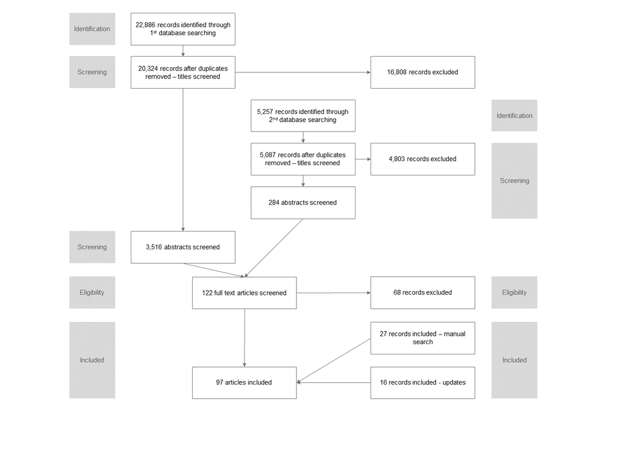

The 97 studies were published between 1925 and 2019 (median publication year 2011) and focused on various aspects of temporary population estimation, including the production of temporary population statistics (Table 1; *Appendix 2*). There has been exponential growth in the number of studies since the first in 1925, with more than third of the studies (35.1%) published since 2015. A total of 56.7% of studies were published as articles followed by 21.6% as reports and 11.3% as conference proceedings or presentations.

The following discussion draws on the content of the included papers that are cited throughout the text as required. Emergency planning (n=22) was the most frequently quoted as reason for producing temporary population estimates followed by understanding service populations (n=7), epidemiology (n=4) and commuting (n=3), many studies directly discussing a domain of application. We next discuss the papers under 6 broad domains; (1) data; (2) methods; (3) the geography of estimates; (4) temporal units; (5) population size and composition; and, (6) reproducibility.

## Data

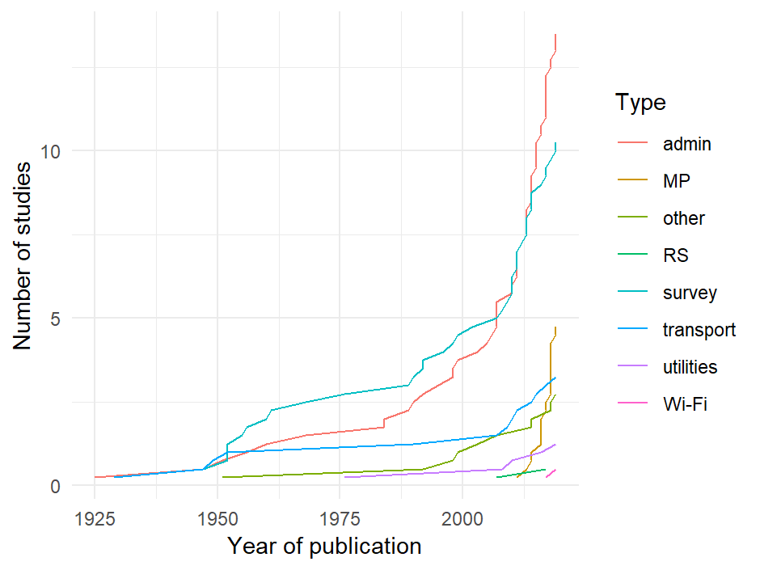

**Figure 2.** Cumulative distribution of year of publication across main themes. Note: Studies belonging to more than one category were weighted by dividing all categories by 1 and assigning equal weights. This procedure excludes the Social Media (SM) category as it only has one member.

The equivalent of this work in the United States employ commuter-adjusted population estimates using the American Community Survey to adjust night-time population counts (McKenzie et al. 2013). Other primarily Census-based studies from the United States include the work from the Seattle City Planning Commission (1951) and Bureau of the Census (1956), Fulton (1984), Gober and Mings (1984), Nelson and Nicholas (1992), McPherson and Brown (2003), Kobayashi, Medina, and Cova (2011), Swanson and Tayman (2011), Hodur and Bangsund (2015), Kim and Ahn (2017), Boeing (2018) and Esri (2018). Each used a wide selection of methods to adjust Census estimates on variety of scales, often accompanied by other data sources. This for example includes, location of work, transportation models or payroll data that helps to determine size and location of daytime or seasonal population.

Census data were also used for estimation and analyses of temporary populations in Australia. Taking advantage of the availability of the place of residence and place of enumeration Bell and Ward (1998) (see also subsequent work in *Appendix 4*) looked at the one day snapshot of mobility of Australians across different years and scales whereas Taylor (1998) used Census for the estimation of mobility of indigenous people. Finally Gao et al. (2014) used Chinese Census data adjusted with figures for tourists, school and patient populations and Qi et al. (2015) extended it with land use models.

Census main advantage is that it provides close to full enumeration of the population, however it also provides only a snapshot of temporary populations on one day or night, every five or ten years. Many form of temporary population mobility are highly seasonal, thus census data will not reflect the population present at other times of the year. Finally, other forms of administrative data such as health service utilization records (Markham, Bath, and Taylor 2013), building (Greger 2015) or second home registries (Adamiak, Pitkänen, and Lehtonen 2017) often complement census providing another data source for methods estimating temporary populations.

Although censuses and surveys tend to lose their position as primary source of data, they still remain crucial part of many estimation attempts. There is a shift from using them as primary sources and into providing more complimentary role, for instance serving as starting points for estimation (–for example, serving as ‘night time population’), delivering time use profiles used to redistribute other data or calibrate models or as a source of validation. For instance, seminal work of LandScan (Bhaduri et al. 2007) used Census as one of the main inputs and Ma et al. (2017) used smart card data to redistribute census (night) counts of population across city.

Less common, yet still significant are studies were based on utilities data (Edmondson and Nantucket Data Platform team n.d.; Goldschmidt and Dahl 1976; McKenzie and Canterford 2016; Monmouth County Planning Board 2008; Rigall-I-Torrent 2010), remote sensing (Stathakis and Baltas 2018; Taubenböck, Roth, and Dech 2007) and Wi-Fi (Kontokosta and Johnson 2017). Contrary to our expectations, social media (SM) data were only used by one study (Lwin, Sugiura, and Zettsu 2016).

### Main trends in methods

The earliest and most straightforward method of deriving temporary populations was to use direct estimates, either from the Census (Census of England and Wales 1921 1925), survey (Thornthwaite 1929) or by combining multiple sources (Breese 1947). These studies took advantage of availability of information about workplaces of individuals (Office for National Statistics 2013), their status of residence (Gober and Mings 1984) or place of enumeration (Bell and Ward 1998) to distinguish between two or more states of population distribution such as night- and daytime.

Alternative approaches used some form of scaling of population counts derived from one or several sources to the whole population either by single or multiple factors. Such approaches were used by both early surveys (Association 1949; Foley 1952) and more contemporary analyses based on MP or Wi-Fi data. In the latter case, various strategies of expansion factors were adopted, some based on penetration rate of MP data provider (Bengtsson et al. 2011), night-time Census population (Deville et al. 2014) or ancillary survey data (Kontokosta and Johnson 2017). Studies either used single factor for entire region (Thomas et al. 2017) or multiple ones, varying them geographically (Batran et al. 2018) or over subgroups of population (Picornell et al. 2018).

Separate strand of research focused on various method of redistribution of one or more sources of data available for larger spatial units to smaller ones. Such approaches used various methods, often mimicking dasymetric approaches used for non-temporary population mapping. LandScan USA (Bhaduri et al. 2007) is an example of such project with largest spatial coverage for instance whereas Martin et al. (2015) model for Southampton is an example of more spatially and temporally detailed approach. Redistribution approach usually uses some ancillary data such as land use (Batista e Silva et al. 2017) or building type (Greger 2015) and apart from Census or surveys could also use MP (Järv, Tenkanen, and Toivonen 2017) or transportation data (Ma et al. 2017) as input.

Temporary populations were also estimated using various equation-based techniques. These methods used generic or area-specific equation to derive counts of temporary residents from usual residents subtracting departures and adding arrivals to a spatial unit in given time (Yong li 1998). For instance JTW data could be used to capture working population (McKenzie et al. 2013), second home users and usage could be used to capture seasonal populations in specific areas (Adamiak, Pitkänen, and Lehtonen 2017) or sales tax data could be used to derive equivalent residents (Thakur 2018). Additionally, separate estimates could be derived for subgroups of population (Swanson and Tayman 2011) or for temporal units using seasonal coefficient derived from night-time satellite imagery (Stathakis and Baltas 2018).

Finally, large number of modelling and simulation approaches were tested more recently with various forms of data inputs. That ranged from agent based simulation (Kashiyama, Pang, and Sekimoto 2017; Walker and Barros 2012), cellular automaton model (Khakpour and Rød 2016), to the use of neural networks (Chen et al. 2018; Liu et al. 2018)

### Captured populations

Majority of studies focused on general populations - either overall or restricted to working population. Such focus was often driven not by the theoretical or practical considerations but rather by availability of the data. For instance many studies based on MP data do not have access to any information on the users.

Examples of specific segments of population captured by the studies include retired individuals (Rose and Kingma 1989), snowbirds (Happel and Hogan 2002), pupils (Campbell 2010), summer resort population (Erickson 1961; Goldschmidt and Dahl 1976), second home users (Adamiak, Pitkänen, and Lehtonen 2017) or indigenous population (Warchivker, Tjapangati, and Wakerman 2000). Focus on specific population might also be a result of focusing on functional area such as university campus (Charles-Edwards and Bell 2013).

### National coverage & geographical breakdown

Only 17.5% of studies reported on estimates created for the whole country. USA was the most represented with five studies, followed by Australia and England & Wales. Only one developing country (Nepal, Wilson et al. 2016) was represented and one study reported on two countries (Deville et al. 2014). Studies covering only part of the coutry were again most frequent in USA. That was followed by China, Austrlia, Japan and UK. A handful of developing nations were included as well. Slightly more than half of the studies were focused on a single city.

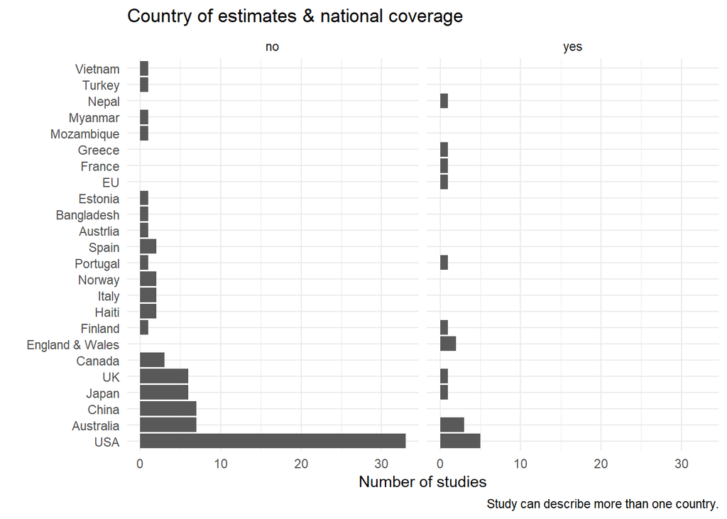

### Spatial unit of estimates

Two types of units dominated estimates: 53.6% studies used some form of administrative units and 28.9% various size of regular grid tessalating area of interest. Other type of unts ranged from whole city to individual points, nodes or Vornoi polygons.Note that studies could report on more than one type of units.

### Number of spatial units

There was a great variation in the number of spatial units used to produce estimates ranging from 1 to 52,000 with median value of 32. 10 studies reported on single spatial unit of various size such as island (Edmondson and Nantucket Data Platform team n.d.), administrative region (Fehr & Peers 2014), city (Goldschmidt and Dahl 1976) or campus (Charles-Edwards and Bell 2013). Studies reporting on larger amount of units provided estimates on building level (Ara 2014) or used high resolution grids (Adamiak, Pitkänen, and Lehtonen 2017) or administrative areas (McKenzie et al. 2013), often with national or large-area coverage. 47 studies did not report exact number of spatial units.

### Daytime & temporal unit of estimates

Majority of studies (74.2%) reported on daytime populations. That has been reflected in the choice of the temporal units of the estimates - 35.1% of studies used minutes or hours as time scale. The second most common unit was split between daytime and nightime estimates (21.6%) or only daytime (14.4%).

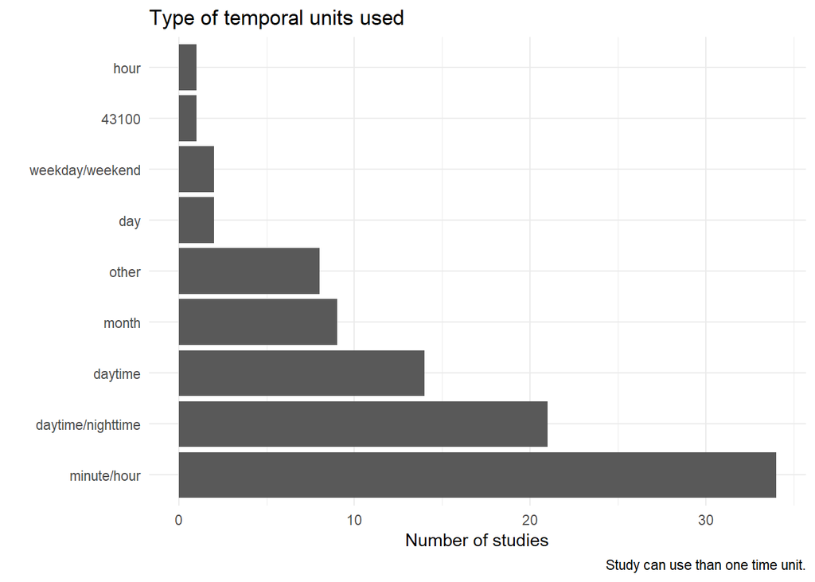

### Estimated population size

There was a great variation in the size of estimated populations, ranging from 1 868 to 53,349,074 with median value of 343,956. When the size of dataset was taken into account these figures ranged from 44 000 to 2,300,000,000 with median value of 19,724,307. Combining these two sources of information, largest populations were used or estimated when MP data were used, followed by smaller amount of transport-based studies. Other large studies used various forms of tax data.

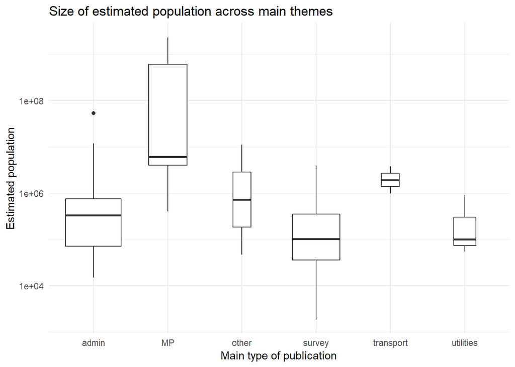

**Note:* Main category used. Box width proportional to number of studies. Studies that did not report on estimated population size had it replaced with size of dataset whenever possible. See main text for abbreviations of types.

### Estimates & software/code availability

60.8% of studies did not report estimates nor indicated any way where they could be obtained. Similarly, large ampount of studies did not report on type of software and/or code used to produce them. In some cases, particularly when relatively simple methods were used (for instance equation based) that would not limit reproducibility or replicability of the studies or possibility to implement them in different settings. However, for many studies, particularly based on proprietary data, the possibility of using the estimates in different areas or extending or validating the methods used will be seriously limited.

### Validation

Similarly to the lack of estimates and software availability, the validation of the results was not a common practice. Only 37.1% reported on some attempt to validate results. However, even if that was attempted the results were mostly simply compared or correlated alternative measure such as nightime population distribution. Lack of data was often quoted as a main reason.

### Purpose of study

Emergency planning was the most frequently quoted as reason for producing estimates followed by smaller amount of studies focused on service populations estimation, epidemiology and commuting.

```
##
## Purpose <character>
## # total N=49  valid N=49  mean=6.29  sd=2.68
##
##                        val frq raw.prc valid.prc cum.prc
##         emergency planning  22   44.90     44.90   44.90
##         service population   7   14.29     14.29   59.18
##               epidemiology   4    8.16      8.16   67.35
##                  commuting   3    6.12      6.12   73.47
##                   mobility   2    4.08      4.08   77.55
##                   planning   2    4.08      4.08   81.63
##                    tourism   2    4.08      4.08   85.71
##                  transport   2    4.08      4.08   89.80
##  characteristics of movers   1    2.04      2.04   91.84
##        counterurbanization   1    2.04      2.04   93.88
##   creation of open dataset   1    2.04      2.04   95.92
##           travel behaviour   1    2.04      2.04   97.96
##     vehicle route planning   1    2.04      2.04  100.00
##                       <NA>   0    0.00        NA      NA
```

Important extension of this work was a report by Markham and colleagues (2013) which discussed challenges involved in estimation of indigenous service populations.

# Conclusions

Large body of literature on similar topics that have potential overlap such as

- estimates of overall pops (such as WorldPop (Tatem 2017) etc.)
- MP use (without pop est) >> seminal examples like (Calabrese et al. 2006) and (Silm and Ahas 2010)
- SM use (without pop est)
- Twitter (Brogueira, Batista, and Carvalho 2016)
- Snapchat (Juhász and Hochmair 2018)
- search engine data (Li et al. 2019)
- analyses focusing on mobility rather than stocks and flow estimation (Gonzalez, Hidalgo, and Barabasi 2008)
- tourism
- tourist arrivals - here some methods could be adapted to TEMPO for instance
- traveler populations at transportation terminals (Jochem et al. 2013)
- forecasting tourist volume with search engine data (Li et al. 2018), Google Analytics (Gunter and Önder 2016), Google Trends (Önder 2017)
- crowd estimation and event monitoring
- more classic approach at demonstrations (Yip et al. 2010)
- agent-based modelling (Chow 2018)
- social media (Sims et al. 2017)
- bluetooth (Versichele et al. 2012)
- MP (Mamei and Colonna 2016)
- Instagram (Botta, Moat, and Preis 2019)
- pedestrian movements
- using GPS & MP (Mizzi et al. 2018)
- using Wi-Fi & Bluetooth (Böhm, Ryeng, and Haugen 2016)
- buildings occupancy (Stewart et al. 2017)
- animal & ecology studies
- abundance (Melville and Welsh 2009)
- movement (Miller et al. 2019)

But many of these studies never move from the analysis of user base to estimates of pop

Importance of good quality of census and survey data as a basis for other methods.

## Strengths

- first and only of this kind?
- up to date results
- systematizing state of the art
- offers guidance towards future work (terminology, keywords, themes, etc.)

## Limitations

- fragmented field, lack of standards and definitions, difficult to search; 27.8% of studies included were found outside of main searches
- keywords overlap (ex working pop in epi; seasonal pop in ecology)
- keyword imprecision ex floating population in Chinese lit
- lots of grey lit, for instance 21.6% of studies were in form of various reports we might have missed things

## Recomendations

Temporal trends in publication counts indicate that the field is accelerating. 16.5% of studies included were found by monitoring search engine updates. That points to even more urgent need for standardizing and systematizing field.

- guideline for systematic reporting of temporary populations estimates
- using Liao et al. (2018) life cycle - ideas on each stage of development (collection, compilation, analysis & communication)
- standardization of terminology & keywords
- encourage to share methodology in more detail, preferably with software/code
- encourage to share estimates, if original data not available then synthetic data following methodology

# Table 1

| Characteristic | Value | n / median | % / min; max |
| --- | --- | --- | --- |
| Year of publication |  | 2011 | 1925; 2019 |
| Study region | single city | 51 | 52.58 |
|  | country | 17 | 17.53 |
|  | admin region | 15 | 15.46 |
|  | multiple cities | 11 | 11.34 |
|  | undefined | 3 | 3.09 |
| Regions for estimates* | admin | 52 | 50 |
|  | grid | 28 | 26.92 |
|  | custom | 7 | 6.73 |
|  | points | 7 | 6.73 |
|  | city | 4 | 3.85 |
|  | building | 3 | 2.88 |
|  | Voronoi | 2 | 1.92 |
|  | node | 1 | 0.96 |
| Number of regions for estimates |  | 32 | 1; 52,000 |
| Size of estimated population |  | 343,956 | 1,868; 53,349,074 |
| Size of dataset |  | 19,724,307 | 44,000; 2,300,000,000 |

# Bibliography

Adamiak, C., Pitkänen, K., and Lehtonen, O. (2017). Seasonal residence and counterurbanization: The role of second homes in population redistribution in Finland. *GeoJournal* 82:1035–1050. doi:10.1007/s10708-016-9727-x Seasonal.

Ara, S. (2014). Impact of Temporal Population Distribution on Earthquake Loss Estimation: A Case Study on Sylhet, Bangladesh. *International Journal of Disaster Risk Science* 5(4):296–312. doi:10.1007/s13753-014-0033-2.

Association, N.Y.R.P. (1949). Persons and Vehicles Entering Manhattan South of 61st Street, 1924-1948. *Regional Plan Bulletin* 74.

Batista e Silva, F., Rosina, K., Schiavina Marcello, M., Marin, M., Freire, S., Craglia, M., and Lavalle, C. (2017). Spatiotemporal mapping of population in Europe: The ‘ENACT’ project in a nutshell. *57th European Regional Science Association (ERSA) Congress*.

Batran, M., Mejia, M., Kanasugi, H., Sekimoto, Y., Shibasaki, R., Batran, M., Mejia, M.G., Kanasugi, H., Sekimoto, Y., and Shibasaki, R. (2018). Inferencing Human Spatiotemporal Mobility in Greater Maputo via Mobile Phone Big Data Mining. *ISPRS International Journal of Geo-Information* 7(7):259. doi:10.3390/ijgi7070259.

Bell, M. (2000). Data, theory, method: Understanding circulation in Austrália. *10th Biennial Conference of the Australian Population Association*.

Bell, M. (2004). *Measuring Temporary Mobility: Dimensions and Issues*. Queensland Centre for Population Research School of Geography, Planning and Architecture, The University of Queensland.: pages.

Bell, M. and Ward, G. (1998). Patterns of Temporary Mobility in Australia: Evidence from the 1991 Census. *Australian Geographical Studies* 36(1):58–81. doi:10.1111/1467-8470.00039.

Bell, M. and Ward, G. (2000). Comparing temporary mobility with permanent migration. *Tourism Geographies* 2(1):87–107. doi:10.1080/146166800363466.

Bengtsson, L., Lu, X., Thorson, A., Garfield, R., and Schreeb, J. von (2011). Improved Response to Disasters and Outbreaks by Tracking Population Movements with Mobile Phone Network Data: A Post-Earthquake Geospatial Study in Haiti. *PLOS Medicine* 8(8):e1001083. doi:10.1371/journal.pmed.1001083.

Bhaduri, B., Bright, E., Coleman, P., and Urban, M.L. (2007). LandScan USA: A high-resolution geospatial and temporal modeling approach for population distribution and dynamics. *GeoJournal* 69(1-2):103–117. doi:10.1007/s10708-007-9105-9.

Boeing, G. (2018). Estimating local daytime population density from census and payroll data. *Regional Studies, Regional Science* 5(1):179–182. doi:10.1080/21681376.2018.1455535.

Botta, F., Moat, H.S., and Preis, T. (2019). Measuring the size of a crowd using Instagram. *Environment and Planning B: Urban Analytics and City Science*:2399808319841615. doi:10.1177/2399808319841615.

Böhm, M.F., Ryeng, E.O., and Haugen, T. (2016). Evaluating the usage of Wi-Fi and Bluetooth based sensors for pedestrian counting in urban areas. *European Transport Conference 2016*:24.

Breese, G.W. (1947). *Daytime Population of the Central Business District of Chicago with Particular Reference to the Factor of Transportation*. University of Chicago.

Brogueira, G., Batista, F., and Carvalho, J.P. (2016). Using geolocated tweets for characterization of Twitter in Portugal and the Portuguese administrative regions. *Social Network Analysis and Mining* 6(1):37. doi:10.1007/s13278-016-0347-8.

Bureau of the Census (1956). *Population Estimates for Survival Planing*. Washington, D.C.: Department of Commerce.: pages.

Calabrese, F., Ratti, C., Calabrese, F., and Ratti, C. (2006). Real Time Rome. *Networks and Communication Studies*:3–4.

Campbell, N. (2010). *Developing an extensible solution for modelling daytime population movement*. [PhD thesis].

Census of England and Wales 1921 (1925). *Workplaces*. London: HMSO.: pages.

Charles-Edwards, E. (2011). *Modelling flux: Towards the estimation of small area temporary populations in Australia*. [PhD]. The University of Queensland.

Charles-Edwards, E. and Bell, M. (2013). Estimating the Service Population of a Large Metropolitan University Campus. *Applied Spatial Analysis and Policy* 6(3):209–228. doi:10.1007/s12061-012-9079-y.

Charles-Edwards, E. and Panczak, R. (2018). Elsewhere in Australia: A snapshot of temporary mobility on the night of the 2016 Census. *Australian Population Studies* 2(1):14–25.

Charles-Edwards, E., Panczak, R., Corcoran, J., and Bell, M. (n.d.). A framework for official temporary population statistics. *Journal of Official Statistics*.

Chen, J., Pei, T., Shaw, S.-L., Lu, F., Li, M., Cheng, S., Liu, X., and Zhang, H. (2018). Fine-grained prediction of urban population using mobile phone location data. *International Journal of Geographical Information Science* 0(0):1–17. doi:10.1080/13658816.2018.1460753.

Chow, T.E. (2018). A crowdsourcingGeocomputational framework of mobile crowd simulation and estimation. *Cartography and Geographic Information Science* 0(0):1–19. doi:10.1080/15230406.2018.1524314.

Collins, A. and Greaves, S. (2007). Daytime population tracking for planning and pollution exposure assessment. *Road and Transport Research Journal* 16(1):55–68.

Deville, P., Linard, C., Martin, S., Gilbert, M., Stevens, F.R., Gaughan, A.E., Blondel, V.D., and Tatem, A.J. (2014). Dynamic population mapping using mobile phone data. *Proceedings of the National Academy of Sciences* 111(45):15888–15893. doi:10.1073/pnas.1408439111.

Edmondson, B. and Nantucket Data Platform team (n.d.). *Making It Count. A Data-Driven Look at Nantucket’s Dynamic Population*. Nantucket Data Platform.: pages.

Elliott, J.H., Turner, T., Clavisi, O., Thomas, J., Higgins, J.P.T., Mavergames, C., and Gruen, R.L. (2014). Living Systematic Reviews: An Emerging Opportunity to Narrow the Evidence-Practice Gap. *PLoS Medicine* 11(2):1–6. doi:10.1371/journal.pmed.1001603.

Erickson, R.B. (1961). Measuring resort population increases. *The Professional Geographer* 13(4):16–19. doi:10.1111/j.0033-0124.1961.134_16.x.

Esri (2018). *Methodology Statement: 2018 Esri Daytime Population*. Redlands.: pages.

Fehr & Peers (2014). *Napa County Travel Behavior Study*.: pages.

Foley, D.L. (1952). The daily movement of population into central business districts. *American Sociological Review* 17(5):538–543.

Foley, D.L. (1954). Urban daytime population: A field for demographic-ecological analysis. *Social Forces* 32(4):323–330. doi:10.2307/2574113.

Freire, S. (2010). Modeling of Spatiotemporal Distribution of Urban Population at High Resolution for Risk Assessment and Emergency Management. In: *Geographic Information and Cartography for Risk and Crisis Management*. Springer, Berlin, Heidelberg: 53–67. doi:10.1007/978-3-642-03442-8_4.

Fulton, P.N. (1984). Estimating the daytime population with the urban transportation planning package. *Transportation Research Record* 981:25–27.

Galvez, J. and McLarty, C. (1996). Measurement of Florida temporary residents using a telephone survey. *Journal of Economic and Social Measurement* 22(1):25–42. doi:10.3233/JEM-1996-22102.

Gao, X., Yuan, H., Qi, W., and Liu, S. (2014). Assessing the Social and Economic Vulnerability of Urban Areas to Disasters: A case study in Beijing, China. *International Review for Spatial Planning and Sustainable Development* 2(1):42–62. doi:10.14246/irspsd.2.1_42.

Gober, P. and Mings, R.C. (1984). A Geography of Nonpermanent Residence in the U.S. *Professional Geographer* 36(2):164–173. doi:10.1111/j.0033-0124.1984.00164.x.

Goldschmidt, P.G. and Dahl, A.W. (1976). Demoflush Estimating Population in Seasonal Resort Communities. *Growth and Change* 7(2):44–48. doi:10.1111/j.1468-2257.1976.tb00305.x.

Gonzalez, M.C., Hidalgo, C.A., and Barabasi, A.L. (2008). Understanding individual human mobility patterns. 453(June). doi:10.1038/nature06958.

Gough, D. (2015). Qualitative and mixed methods in systematic reviews. *Systematic Reviews* 4(1):181. doi:10.1186/s13643-015-0151-y.

Graebert, M.B., Wyckoff, M., and Bretz, L. (2014). *Northwest Michigan Seasonal Population Analysis*. Michigan State University Land Policy Institute.: pages.

Greger, K. (2015). Spatio-Temporal Building Population Estimation for Highly Urbanized Areas Using GIS. *Transactions in GIS* 19(1):129–150. doi:10.1111/tgis.12086.

Gunter, U. and Önder, I. (2016). Forecasting city arrivals with Google Analytics. *Annals of Tourism Research* 61:199–212. doi:10.1016/j.annals.2016.10.007.

Happel, S.K. and Hogan, T.D. (2002). Counting snowbirds: The importance of and the problems with estimating seasonal populations. *Population Research and Policy Review* 21(3):227–240. doi:10.1023/A:1019560405310.

Himoto, K. and Kimata, J. (2014). A Model for the Spatio-temporal Distribution of Population using Country-Wide Statistical Data and Its Application to the Estimation of Human Exposure to Disasters. In: *Improving Disaster Resilience and Mitigation - IT Means and Tools*. Springer, Dordrecht: 73–87. doi:10.1007/978-94-017-9136-6_5.

Hodur, N.M. and Bangsund (2015). *Service Population Estimates for City of Williston*. Fargo: North Dakota State University.: pages.

Horanont, T. and Shibasaki, R. (2010). Estimate ambient population density: Discovering the current flow of the city..

Institute for Research in Social Science University of North Carolina (1952). *Population Distribution, Spatial and Temporal;a Study of Daytime -Nighttime Differentials in the Proportional Distribution of the Total Population of Selected Urban Areas*. Chapel Hill.

Järv, O., Tenkanen, H., and Toivonen, T. (2017). Enhancing spatial accuracy of mobile phone data using multi-temporal dasymetric interpolation. *International Journal of Geographical Information Science* 31(8):1630–1651. doi:10.1080/13658816.2017.1287369.

Jochem, W.C., Sims, K., Bright, E.A., Urban, M.L., Rose, A.N., Coleman, P.R., and Bhaduri, B.L. (2013). Estimating traveler populations at airport and cruise terminals for population distribution and dynamics. *Natural Hazards* 68(3):1325–1342. doi:10.1007/s11069-012-0441-9.

Juhász, L. and Hochmair, H.H. (2018). Analyzing the spatio the spatio-temporal dynamics of Snapchat. *AGILE 2018 Workshop: VGI-ALIVE - AnaLysis, Integration, Vision, Engagement*.

Kashiyama, T., Pang, Y., and Sekimoto, Y. (2017). Open PFLOW: Creation and evaluation of an open dataset for typical people mass movement in urban areas. *Transportation Research Part C: Emerging Technologies* 85:249–267. doi:10.1016/j.trc.2017.09.016.

Kavanaugh, P. (1990). A method for estimating daytime population by small area geography. *Proceedings of the 1990 Urban and Regional Information Systems Association Conference*:150–164.

Khakpour, M. and Rød, J.K. (2016). An attraction-based cellular automaton model for generating spatiotemporal population maps in urban areas. *Environment and Planning B: Planning and Design* 43(2):297–319. doi:10.1177/0265813515604262.

Khodabandelou, G., Gauthier, V., El-Yacoubi, M., and Fiore, M. (2016). Population estimation from mobile network traffic metadata. *2016 IEEE 17th International Symposium on A World of Wireless, Mobile and Multimedia Networks (WoWMoM)*:1–9. doi:10.1109/WoWMoM.2016.7523554.

Khodabandelou, G., Gauthier, V., Fiore, M., and Yacoubi, M.A.E. (2018). Estimation of Static and Dynamic Urban Populations with Mobile Network Metadata. *IEEE Transactions on Mobile Computing*:1–1. doi:10.1109/TMC.2018.2871156.

Kim, H. and Ahn, J.-S.(. (2017). Modelling Daytime Population Distribution for Emergency Response and Social Vulnerability Assessment. *Journal of Korean Geographical Society* 51(3):335–346.

Kobayashi, T., Medina, R.M., and Cova, T.J. (2011). Visualizing Diurnal Population Change in Urban Areas for Emergency Management. *The Professional Geographer* 63(1):113–130. doi:10.1080/00330124.2010.533565.

Kontokosta, C.E. and Johnson, N. (2017). Urban phenology: Toward a real-time census of the city using Wi-Fi data. *Computers, Environment and Urban Systems* 64:144–153. doi:10.1016/j.compenvurbsys.2017.01.011.

Lamb, G. (1999). *Estimating the Seasonal Population of Door County*.: pages.

Lau, K.H. (2009). A GIS-based Stochastic Approach to Generating Daytime Population Distributions for Vehicle Route Planning. *Transactions in GIS* 13(5-6):481–502. doi:10.1111/j.1467-9671.2009.01175.x.

Li, J., Li, J., Yuan, Y., and Li, G. (2019). Spatiotemporal distribution characteristics and mechanism analysis of urban population density: A case of Xi’an, Shaanxi, China. *Cities* 86:62–70. doi:10.1016/j.cities.2018.12.008.

Li, S., Chen, T., Wang, L., and Ming, C. (2018). Effective tourist volume forecasting supported by PCA and improved BPNN using Baidu index. *Tourism Management* 68:116–126. doi:10.1016/j.tourman.2018.03.006.

Liao, C., Brown, D., Fei, D., Long, X., Chen, D., and Che, S. (2018). Big data-enabled social sensing in spatial analysis: Potentials and pitfalls. *Transactions in GIS*. doi:10.1111/tgis.12483.

Liu, Z., Ma, T., Du, Y., Pei, T., Yi, J., and Peng, H. (2018). Mapping hourly dynamics of urban population using trajectories reconstructed from mobile phone records. *Transactions in GIS*:1–20. doi:10.1111/tgis.12323.

Lwin, K.K., Sugiura, K., and Zettsu, K. (2016). SpaceTime multiple regression model for grid-based population estimation in urban areas. *International Journal of \ldots*.

Ma, Y.J., Xu, W., Zhao, X.J., and Li, Y. (2017). Modeling the Hourly Distribution of Population at a High Spatiotemporal Resolution Using Subway Smart Card Data: A Case Study in the Central Area of Beijing. *ISPRS International Journal of Geo-Information* 6(5). doi:10.3390/ijgi6050128.

Mamei, M. and Colonna, M. (2016). Estimating attendance from cellular network data. *International Journal of Geographical Information Science* 30(7):1281–1301. doi:10.1080/13658816.2015.1127378.

Markham, F., Bath, J., and Taylor, J. (2013). *New Directions in Indigenous Service Population Estimation*. Centre for Aboriginal Economic Policy Research, The Australian National University.: pages.

Martin, D., Cockings, S., and Leung, S. (2015). Developing a Flexible Framework for Spatiotemporal Population Modeling. *Annals of the Association of American Geographers* 105(4):754–772. doi:10.1080/00045608.2015.1022089.

Martí, P., Serrano-Estrada, L., and Nolasco-Cirugeda, A. (2018). Social Media data: Challenges, opportunities and limitations in urban studies. *Computers, Environment and Urban Systems*. doi:10.1016/j.compenvurbsys.2018.11.001.

McKenzie, B., Koerber, W., Fields, A., Benetsky, M., and Rapino, M. (2013). *Commuter-Adjusted Population Estimates: ACS 2006-10*. Journey to Work and Migration Statistics Branch, U.S. Census Bureau.

McKenzie, F. and Canterford, S. (2016). *Demographics for Fire Risk Analysis Regional Victoria and Peri-Urban Melbourne*. Melbourne, Austrlia: Department of Environment, Land, Water and Planning.: pages.

McPherson, T. and Brown, M. (2003). *U.S. Day and Night Population Database (Revision 2.0) - Description of Methodology*. Los Alamos National Laboratory.: pages.

Melville, G. and Welsh, A. (2009). Estimating Species Abundance. In: Wilson, S. R. and Burden, C. (eds.). *Biometrics - Volume I*. Oxford, UK: EOLSS Publishers.

Menzler, F.A.A. (1952). An estimate of the day-time population of London. *Journal of the Town Planning Institute* 38(5):116–120.

Miller, H.J., Dodge, S., Miller, J., and Bohrer, G. (2019). Towards an integrated science of movement: Converging research on animal movement ecology and human mobility science. *International Journal of Geographical Information Science* 0(0):1–22. doi:10.1080/13658816.2018.1564317.

Mizzi, C., Fabbri, A., Rambaldi, S., Bertini, F., Curti, N., Sinigardi, S., Luzi, R., Venturi, G., Davide, M., Muratore, G., Vannelli, A., and Bazzani, A. (2018). Unraveling pedestrian mobility on a road network using ICTs data during great tourist events. *EPJ Data Science* 7(1):44. doi:10.1140/epjds/s13688-018-0168-2.

Moher, D., Liberati, A., Tetzlaff, J., Altman, D.G., Altman, D., Antes, G., Atkins, D., Barbour, V., Barrowman, N., Berlin, J.A., Clark, J., Clarke, M., Cook, D., D’Amico, R., Deeks, J.J., Devereaux, P.J., Dickersin, K., Egger, M., Ernst, E., Gøtzsche, P.C., Grimshaw, J., Guyatt, G., Higgins, J., Ioannidis, J.P., Kleijnen, J., Lang, T., Magrini, N., McNamee, D., Moja, L., Mulrow, C., Napoli, M., Oxman, A., Pham, B., Rennie, D., Sampson, M., Schulz, K.F., Shekelle, P.G., Tovey, D., and Tugwell, P. (2009). Preferred reporting items for systematic reviews and meta-analyses: The PRISMA statement. *PLoS Medicine* 6(7). doi:10.1371/journal.pmed.1000097.

Monmouth County Planning Board (2008). *Summer Coastal Population Study*.: pages.

Nelson, A.C. and Nicholas, J.C. (1992). Estimating functional population for facility planning. *Journal of Urban Planning and Development* 118(2).

Office for National Statistics (2013). *2011 Census: The Workday Population of England and Wales - an Alternative 2011 Census Output Base*. Office for National Statistics.: pages.

Önder, I. (2017). Forecasting tourism demand with Google trends: Accuracy comparison of countries versus cities. *International Journal of Tourism Research* 19(6):648–660. doi:10.1002/jtr.2137.

Picornell, M., Ruiz, T., Borge, R., García-Albertos, P., Paz, D. de la, and Lumbreras, J. (2018). Population dynamics based on mobile phone data to improve air pollution exposure assessments. *Journal of Exposure Science & Environmental Epidemiology*:1. doi:10.1038/s41370-018-0058-5.

Qi, W., Liu, S., Gao, X., and Zhao, M. (2015). Modeling the spatial distribution of urban population during the daytime and at night based on land use: A case study in Beijing, China. *Journal of Geographical Sciences* 25(6).

Rigall-I-Torrent, R. (2010). Estimating overnight de facto population by forecasting symptomatic variables: An integrated framework. *Journal of Forecasting* 29(7):635–654. doi:10.1002/for.1166.

Roddis, S. (1996). Metropolitan Activity Profiles - A New Perspective on Demand. *20th Australasian Transport Research Forum Conference*.

Rose, L.S. and Kingma, H.L. (1989). Seasonal Migration of Retired Persons: Estimating Its Extent and Its Implications for the State of Florida. *Journal of Economic and Social Measurement* 15(1):91–104. doi:10.3233/JEM-1989-15106.

Schmitt, R.C. (1956). Estimating Daytime Populations. *Journal of the American Planning Association* 22(2):83–85. doi:10.1080/01944365608979227.

Seattle City Planning Commission (1951). *Daytime and Night-Time Population Distribution in Metropolitan Seattle: April, 1950*.: pages.

Sekimoto, Y., Shibasaki, R., Kanasugi, H., Usui, T., and Shimazaki, Y. (2011). PFlow: Reconstructing People Flow Recycling Large-Scale Social Survey Data. *IEEE Pervasive Computing* 10(4):27–35. doi:10.1109/MPRV.2011.43.

Sharp, H. (1955). The Non-Residential Population of the Central Business District. *Land Economics* 31(4):378–381. doi:10.2307/3159307.

Silm, S. and Ahas, R. (2010). The seasonal variability of population in Estonian municipalities. *Environment and Planning A* 42(10):2527–2546. doi:10.1068/a43139.

Sims, K.M., Weber, E.M., Bhaduri, B.L., Thakur, G.S., and Resseguie, D.R. (2017). Application of Social Media Data to High-Resolution Mapping of a Special Event Population. In: *Advances in Geocomputation*. Springer, Cham: 67–74. doi:10.1007/978-3-319-22786-3_7.

Sleeter, R. and Wood, N. (2006). Estimating daytime and nighttime population density for coastal communities in Oregon. *44th Urban and Regional Information Systems Association Annual Conference*.

Smith, G., Arnot, C., Fairburn, J., and Walker, G. (2005). *A National Population Data Base for Major Accident Hazard Modelling*. Health and Safety Executive.: pages.

Smith, S.K. (1987). How to tally temporary populations. *American Demographics* 9(7):44–5.

Smith, S.K. (1989). Toward a methodology for estimating temporary residents. *Journal of the American Statistical Association*.

Smith, S.K. and House, M. (2007). Temporary Migration: A Case Study of Florida. *Population Research and Policy Review* 26(4):437–454.

Stathakis, D. and Baltas, P. (2018). Seasonal population estimates based on night-time lights. *Computers, Environment and Urban Systems* 68:133–141. doi:10.1016/j.compenvurbsys.2017.12.001.

Stewart, R., Piburn, J., Weber, E., Urban, M., Morton, A., Thakur, G., and Bhaduri, B. (2017). Can Social Media Play a Role in the Development of Building Occupancy Curves? *Advances in Geocomputation*:59–66.

Stutz, F.P., Parrott, R., and Kavanaugh, P. (1992). Charting urban space-time population shifts with trip generation models. *Urban Geography* 13(5):468–474. doi:10.2747/0272-3638.13.5.468.

Swanson, D.A. and Tayman, J. (2011). On estimating a de facto population and its components. *Review of Economics & Finance* 1.

Tatem, A.J. (2017). WorldPop, open data for spatial demography. *Scientific Data* 4:170004.

Taubenböck, H., Roth, A., and Dech, S. (2007). Linking structural urban characteristics derived from high resolution satellite data to population distribution. *Urban and Regional Data Management: UDMS 2007 Annual*.

Taylor, J. (1998). Measuring short-term population mobility among indigenous Australians: Options and implications. *Australian Geographer* 29(1):125–137. doi:10.1080/00049189808703207.

Terada, M., Nagata, T., and Kobayashi, M. (2013). Population Estimation Technology for Mobile Spatial Statistics. *NTT DOCOMO Technical journal* 14(3):10–15.

Thakur, R. (2018). *A Methodology to Account for Seasonal Population Shifts in North Carolina*. [M.S.]. United States – North Carolina: The University of North Carolina at Charlotte.

Thomas, K.V., Amador, A., Baz-Lomba, J.A., and Reid, M. (2017). Use of Mobile Device Data To Better Estimate Dynamic Population Size for Wastewater-Based Epidemiology. *Environmental Science & Technology* 51(19):11363–11370. doi:10.1021/acs.est.7b02538.

Thornthwaite, C. (1929). *Louisville, Kentucky: A study in urban geography*. [PhD thesis]. Berkeley: Department of Geography, University of California.

Versichele, M., Neutens, T., Delafontaine, M., and Van de Weghe, N. (2012). The use of Bluetooth for analysing spatiotemporal dynamics of human movement at mass events: A case study of the Ghent Festivities. *Applied Geography* 32(2):208–220. doi:10.1016/j.apgeog.2011.05.011.

Walker, L. and Barros, J. (2012). An agent-based population model for Wolverhampton, UK: A spatio-temporal activity based approach to population modelling. *GISRUK*.

Warchivker, I., Tjapangati, T., and Wakerman, J. (2000). The turmoil of Aboriginal enumeration: Mobility and service population analysis in a Central Australian community. *Australian and New Zealand Journal of Public Health* 24(4):444–449. doi:10.1111/j.1467-842X.2000.tb01610.x.

Weir, T.R. (1960). A Survey of the Daytime Population of Winnipeg. *Queen’s Quarterly; Kingston, Ont.* 67:654–664.

Wheeler, J.O. and Brunn, S.D. (2002). An urban geographer before his time: C. Warren Thornthwaite’s 1930 doctoral dissertation. *Progress in Human Geography* 26(4):463–486. doi:10.1191/0309132502ph381ra.

Wilson, R., zu Erbach-Schoenberg, E., Albert, M., Power, D., Tudge, S., Gonzalez, M., Guthrie, S., Chamberlain, H., Brooks, C., Hughes, C., Pitonakova, L., Buckee, C., Lu, X., Wetter, E., Tatem, A., and Bengtsson, L. (2016). Rapid and Near Real-Time Assessments of Population Displacement Using Mobile Phone Data Following Disasters: The 2015 Nepal Earthquake. *PLOS Currents Disasters* Feb 24(Edition 1). doi:10.1371/currents.dis.d073fbece328e4c39087bc086d694b5c.

Wurtele, Z.S. and Wellisch, J.B. (1968). *Population Dynamics: Final Report*. Santa Monica, California: System Development Corporation.: pages.

Yip, P.S.F., Watson, R., Chan, K.S., Lau, E.H.Y., Chen, F., Xu, Y., Xi, L., Cheung, D.Y.T., Ip, B.Y.T., and Liu, D. (2010). Estimation of the Number of People in a Demonstration. *Australian & New Zealand Journal of Statistics* 52(1):17–26. doi:10.1111/j.1467-842X.2009.00562.x.

Yong li, M. (1998). Research in statistical models for mobile population (SMMP). *Cartographic Journal* 35(2):155–164. doi:10.1179/caj.1998.35.2.155.

# Acknowledgments

We would like to thank the authors that responded to queries about details of their work: Christoph Aubrecht, Filipe Batista e Silva, Andrew Collins, Donald G. Janelle, David Martin, Chris Needham, Paola Pucci, Stanley Smith and Martijn Tennekes.